# COMP 162 Final Project

## Introduction

This is the Las Vegas Strip dataset hostedd on the UCI Machine Learning Repository. The dataset can be found at this link: https://archive.ics.uci.edu/dataset/397/las+vegas+strip

The dataset includes 504 hotel reviews between January and August 2015. Some of the most important variables in this dataset are the user country, traveler type, hotel name, amenities of the hotel, the hotel star rating, and the score of the review.

In the code below, the dataset was cleaned correct formatting and number of stars for hotels that are rated 4.5 stars. I also created another column that determines if it is high quality or not depending on the hotel stars. In additions, I encoded the yes/no values for the hotel amenities into 0/1 to help with logistic regression later on.

```python
import matplotlib.pyplot as plt
import numpy as np
import pandas as pd
import seaborn as sns
from sklearn import metrics, model_selection, linear_model, preprocessing

vegas = pd.read_csv("vegas.csv",delimiter = ";")
```

```python
# Cleaning
vegas.loc[vegas['Hotel name'] == "The Cromwell", "Hotel stars"] = 4.5
vegas.loc[vegas['Hotel name'] == "Hilton Grand Vacations on the Boulevard", "Hotel stars"] = 3.5
vegas.loc[vegas['Hotel name'] == "Wyndham Grand Desert", "Hotel stars"] = 3.5
vegas.loc[vegas['Hotel name'] == "Marriott's Grand Chateau", "Hotel stars"] = 3.5
vegas["High Quality"] = vegas["Hotel stars"].map(lambda x: 1 if int(x) >= 4 else 0)
change_cols = ["Pool","Gym","Tennis court","Spa","Casino","Free internet"]
vegas[change_cols] = vegas[change_cols].map(lambda x: 1 if x == 'YES' else 0 if x == 'NO' else x)
```

# Hypothesis and Data Exploration

The first hypothesis and question I had for the data set was what kind of hotels are most popular with families. To answer this question, I created the following plot below.

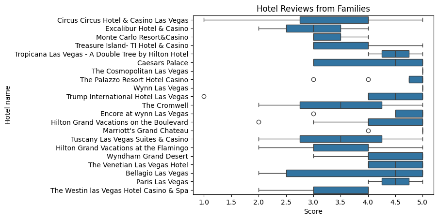

```python
sns.boxplot(data = vegas[vegas["Traveler type"] == "Families"], x = "Score", y = "Hotel name")
plt.title("Hotel Reviews from Families")
plt.savefig("Family_hotel.png", dpi=300, bbox_inches='tight')
```

Based on the boxplot, we see that there are some hotels with a tight distribution of reviews between 4 and 5 stars. These hotels include the Venetian, Paris Las Vegas, and the Tropicana for example. For some hotels, there is a single line, which indicates only 5 star reviews for that hotel.

The next idea I wanted to explore with the data is what are the main demographics for hotel. With the following code I created a barplot that shows the top counts for each hotel, colored by the user/reviewers country.

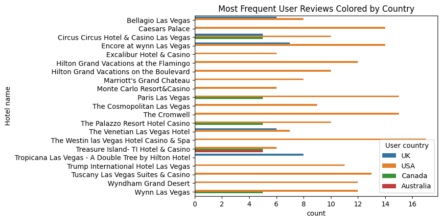

```python
country_counts = vegas.groupby(["Hotel name","User country"]).size().reset_index(name='count')
country_counts = country_counts[country_counts["count"] >= 5]
sns.barplot(y='Hotel name', x='count', hue='User country', data=country_counts)
plt.title("Most Frequent User Reviews Colored by Country")
plt.savefig("Country_plot.png", dpi=300, bbox_inches='tight')
```

From the bar plot, we see that the most common country for hotel reviewers are from the USA, which makes sense since most Las Vegas tourists are from the US. It is also interesting to see that the next most common user countries are from the UK, Canada, and Australia. On the barplot, we also see that for the hotels that do have a high count of foreign tourist reviews, these hotels tend to be more popular and famous to Las Vegas. For example, the Bellagio, Treasure Island, and Circus Circus Hotel are all famous Las Vegas hotels and would be more likely to attract foreign tourists. However, this is not to say that those are the only Las Vegas hotels that get foreign tourists. These are only the tourists that have left a review in the dataset.

# Machine Learning

## Logistic Regression

The first machine learning model that I wanted to test was to see if we can predict what makes a high quality hotel. Using the high quality variable I added in the beginning, I created a logistic regression model based on the amenities of the hotel. I trained the model outputed the confusion matrix and importance of each variable.

```python
X = vegas.drop(["Hotel name","User continent","Member years","Review month","Review weekday","User country","Period of stay","Traveler type","High Quality","Hotel stars","Nr. reviews","Nr. hotel reviews","Helpful votes"],axis = 1)
X_train, X_test, y_train, y_test = model_selection.train_test_split(X,vegas["High Quality"], random_state = 333)
scaler = preprocessing.StandardScaler().fit(X_train)
X_train = pd.DataFrame(scaler.fit_transform(X_train), columns=X_train.columns, index=X_train.index)
reg = linear_model.LogisticRegression().fit(X_train,y_train)
y_pred = reg.predict(X_test)
labels = np.unique(y_test)
cm = metrics.confusion_matrix(y_test, y_pred, labels = np.unique(y_test))
display(pd.DataFrame(cm, index = labels, columns = labels))
display(metrics.accuracy_score(y_test, y_pred))
coef_df = pd.DataFrame(zip(reg.coef_[0], X_train.columns))
display(coef_df)
```

|  | 0 | 1 |
| --- | --- | --- |
| 0 | 0 | 38 |
| 1 | 0 | 88 |

```
0.6984126984126984
```

|  | 0 | 1 |
| --- | --- | --- |
| 0 | 0.221385 | Score |
| 1 | 0.637869 | Pool |
| 2 | -1.680303 | Gym |
| 3 | 0.050286 | Tennis court |
| 4 | 1.699284 | Spa |
| 5 | 0.651311 | Casino |
| 6 | -0.716415 | Free internet |
| 7 | 0.624486 | Nr. rooms |

From the confusion matrix, we see that the logistic regression model does have close to a 70% accuracy, but the model appears to only predict true for every observation. I believe that the model is underfit and does not have enough data to determine what makes a hotel good quality. The dataset does not provide enough data or specifics about each review and the model struggles to find a pattern as a result. I would not recommend this model for prediction since it only predicts true.

## Linear Regression

Following a similar idea from as the logistic regression, I wanted to see if we can predict the number of hotel stars directly using same hotel amenities as the parameters for the linear regression model.

```python
X = vegas.drop(["Hotel name","User continent","Member years","Review month","Review weekday","User country","Period of stay","Traveler type","High Quality","Hotel stars","Nr. reviews","Nr. hotel reviews","Helpful votes"],axis = 1)
X_train, X_test, y_train, y_test = model_selection.train_test_split(X,vegas["Hotel stars"], random_state = 333)
reg = linear_model.LinearRegression().fit(X_train,y_train)
y_pred = reg.predict(X_test)
print("Train R2: " + str(metrics.r2_score(y_train, reg.predict(X_train))))
print("Test R2: " + str(metrics.r2_score(y_test, y_pred)))
print("Train RMSE: "+ str(metrics.mean_squared_error(y_train, reg.predict(X_train))))
print("Test RMSE: "+ str(metrics.mean_squared_error(y_test, y_pred)))
```

```
Train R2: 0.46427200539669355
Test R2: 0.39503910681487553
Train RMSE: 0.31278263974829706
Test RMSE: 0.3810632509495177
```

Looking at the variance and the RMSE from the model, we see similar poor results like the logistic regression model. The poor variance on the training and testing sets possibly show that the model is underfitting or that there is not enough data for the model to find any patterns. Based on the data that we do have, I would say that this model is not fit to make any predictions.

# Ethical Considerations

Overall, I would say this dataset was obtained ethically. The only personal details that could be used to identify someone are the user country and maybe the period of stay. The dataset does not provide much personal details and the reviews were gathered based on public and globally available reviews.

# Conclusions

From this project, I was able to provide an answer to some of the questions I initally had in the beginning. I was able to find that the most popular family hotels were Paris Las Vegas, The Venetian, Encore at Wynn, Palazzo Resort, and the Tropicana. The most common country most hotel reviewers were from are the USA, UK, Canada, and Australia. Lastly, the dataset does not provide enough data to create a model to predict the hotel stars or quality.